# Homework 9

Modified

We 2023-09-13 16:24

Due

Fr 2025-10-17 8:00

Do the following in engineering format.

1. An array of electronic chips is mounted within a sealed rectangular enclosure, and cooling is implemented by attaching an aluminum heat sink $\left(k = 180\frac{W}{mK}\right)$. The base of the heat sink has dimensions of $w_1 = w_2 = 100mm$, while the $6$ fins are of thickness $t = 10mm$ and pitch $S = 18mm$. The fin length is $L_f = 50mm$, and the base of the heat sink has a thickness of $L_b = 10 mm$.

   Figure 1: Fin Diagram

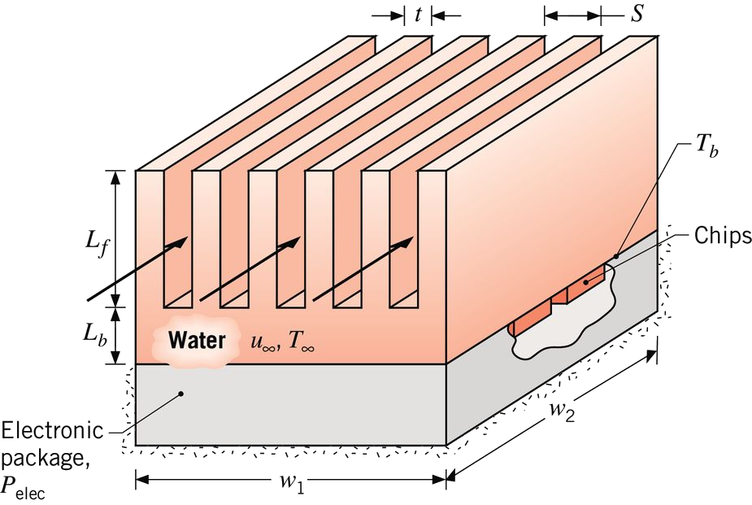

   If cooling is implemented by water flow through the heat sink, with $u_\infty = 3\frac{m}{s}$ and $T_\infty = 17 ^\circ C$, what is the base temperature $T_b$ of the heat sink when power dissipation by the chips is $P_{elec} = 1800W$? The average convection coefficient for surfaces of the fins and the exposed base may be estimated by assuming parallel flow over a flat plate. Properties of the water may be approximated as $k = 0.62\frac{W}{m K}$, $\rho = 995\frac{kg}{m^3}$, $c_p = 4178\frac{J}{kg K}$, $\nu = 7.73 \times 10^{-7} \frac{m^2}{s}$, and $Pr = 5.2$.

   *Answer:* $46.2 ^\circ C$
2. Consider the following fluids, each with a velocity of $V = 2.5 \frac{m}{s}$ and a temperature of $T_\infty = 20 ^\circ C$, in cross flow over a $5 mm$ diameter cylinder maintained at $50 ^\circ C$: atmospheric air, saturated water, and engine oil.
   1. Calculate the rate of heat transfer per unit length, $q^{'}$.

   Figure 2: Pin Fin Configuration

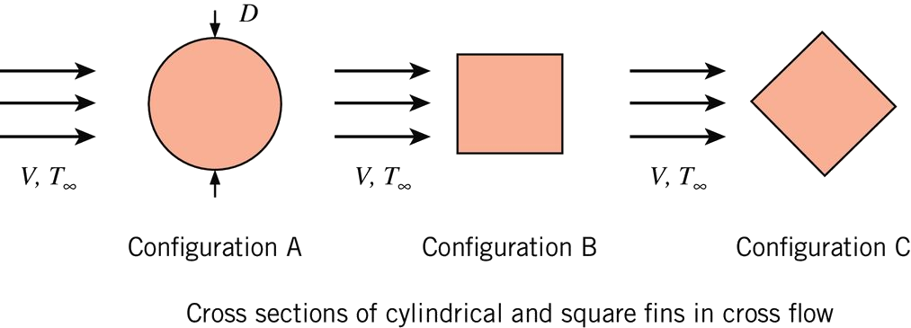

   *Answer: Configuration B*
4. Air at $25 ^\circ C$ flows over a $10 mm$ diameter sphere with a velocity of $25 \frac{m}{s}$, while the surface of the sphere is maintained at $-23 ^\circ C$.
   1. What is the drag force on the sphere?

      *Answer:* $12.54 mN$
   2. What is the rate of heat transfer to the sphere?

      *Answer:* $3.233 W$

Homework submission should be made on [Canvas](https://canvas.latech.edu).